# Categorical Data in R

### Creating Two-Way Tables

Is there an association between gender and self-image? The 2003-2004 National Health & Nuitrition Exam Survey (NHANES) asked participants to describe their own self-image regarding weight. The options were Underweight, About Right, and Overweight.

One way to get the data is to load it from a comma separated values (csv) file into an R data frame and then convert it to a two-way table using the `table()` function.

```r
self.image.df <- read.csv("https://bclins.github.io/spring26/math222/Examples/SelfImage.csv")
summary(self.image.df)
```

```
##     gender           self.image
##  Length:5876        Length:5876
##  Class :character   Class :character
##  Mode  :character   Mode  :character
```

```r
self.image <- table(self.image.df)
self.image
```

```
##         self.image
## gender   About Right Overweight Underweight
##   Female        1175       1730         116
##   Male          1469       1112         274
```

The other way is to manually enter the data as a matrix:

```r
self.image.matrix <- matrix(c(116,274,1175,1469,1730,1112),ncol=2,byrow=T)
colnames(self.image.matrix)=c('Female','Male')
rownames(self.image.matrix)=c('Underweight','About Right','Overweight')
self.image2 <- as.table(self.image.matrix)
self.image2
```

```
##             Female Male
## Underweight    116  274
## About Right   1175 1469
## Overweight    1730 1112
```

Notice that the two tables aren’t the same because they have swapped rows and columns. That’s easy to fix using the `t()` function which transposes the table (swaps the rows and columns).

```r
self.image <- t(self.image)
self.image
```

```
##              gender
## self.image    Female Male
##   About Right   1175 1469
##   Overweight    1730 1112
##   Underweight    116  274
```

### Visualizing Two Categorical Variables

You can make either a bar graph or a mosaic plot for this data, and each can be oriented two ways:

#### Stacked Bar Graph

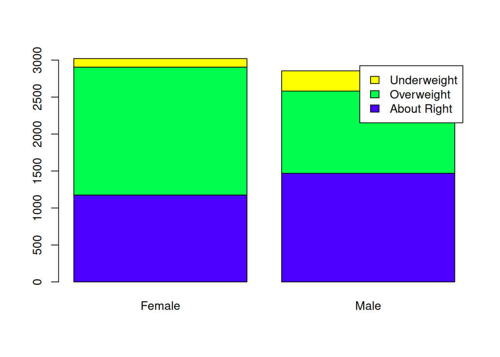

```r
barplot(self.image, col = topo.colors(3), legend=T)
```

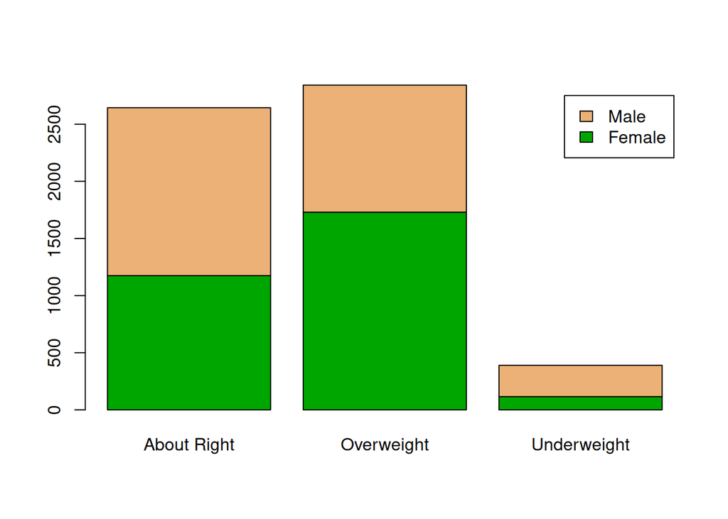

```r
barplot(t(self.image), col = terrain.colors(3), legend=T)
```

#### Stacked Bar Graph Showing Proportions

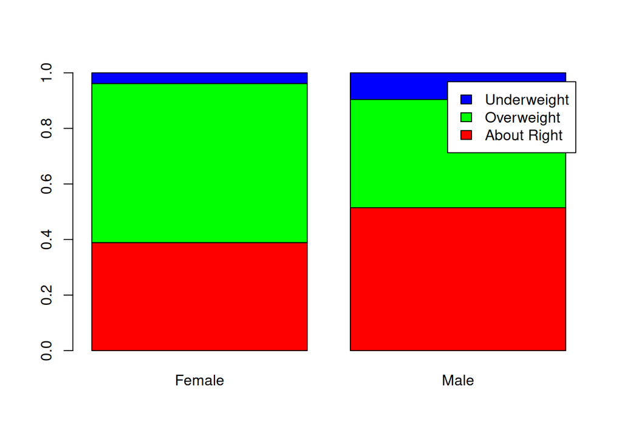

```r
barplot(prop.table(self.image, margin = 2), col = rainbow(3), legend=T)
```

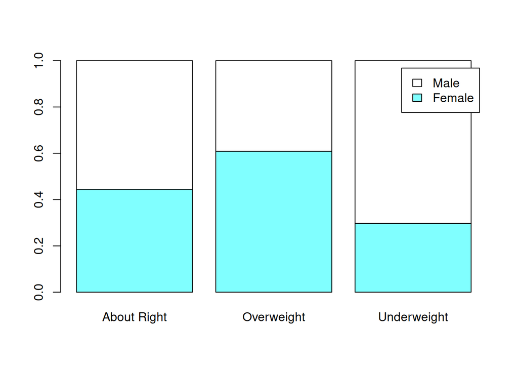

```r
barplot(prop.table(t(self.image), margin = 2), col = cm.colors(3), legend=T)
```

#### Mosaic Plots

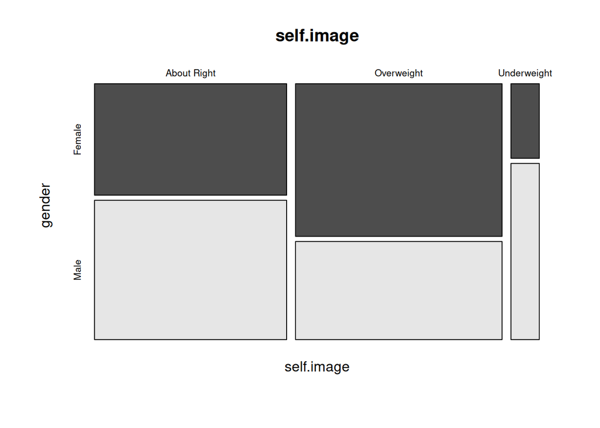

```r
mosaicplot(self.image, col = T, legend=T)
```

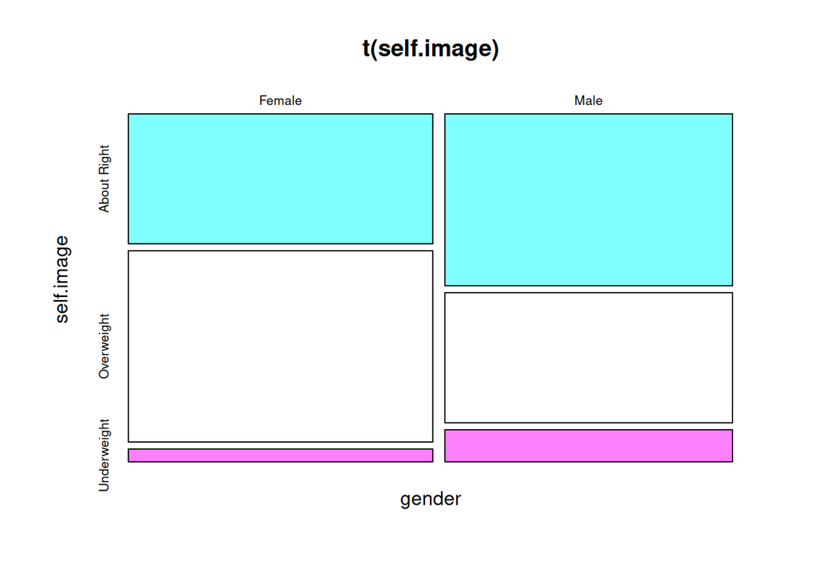

```r
mosaicplot(t(self.image), col = cm.colors(3), legend=T)
```

### Chi-Squared Test

In order to test the hypotheses:

- $H_0$: Gender and self-image are independent in the population.
- $H_A$: Gender and self-image are associated.

We use the R command `chisq.test()`.

```r
prop.test(self.image) # prop.test only works for a table with two columns.
```

```
##
##  3-sample test for equality of proportions without continuity correction
##
## data:  self.image
## X-squared = 226.58, df = 2, p-value < 2.2e-16
## alternative hypothesis: two.sided
## sample estimates:
##    prop 1    prop 2    prop 3
## 0.4444024 0.6087262 0.2974359
```

```r
chisq.test(self.image)
```

```
##
##  Pearson's Chi-squared test
##
## data:  self.image
## X-squared = 226.58, df = 2, p-value < 2.2e-16
```

As you can see, the results are very significant, so we can safely conclude that there is a real association between gender and self-image in the population. It appears that women are significantly more likely to view themselves as overweight.